# PS 15 Section 7 - Multivariate regression

##REMINDERS 1. KNIT AS YOU GO! 2. ALWAYS SET YOUR WORKING DIRECTORY FIRST 3. MAKE SURE YOU KNOW WHAT YOUR VARIABLES ARE (X and Y, ORDER MATTERS) 4. KEEP CHUNKS TOGETHER EVEN IF THE PROBLEM SET SAYS DIFFERENTLY 5. PUT TEXTBOOK ANSWERS UNDER THE QUESTION 6. YOU CAN WORK TOGETHER, BUT PLEASE WRITE ANSWERS IN YOUR OWN WORDS (object names too)

1. Clear your workspace.

```r
rm(list = ls())
# This removes everything in your environment
```

2. Set your working directory and load the NBA data (“nba.RData”).

```r
# setwd("~/UCSB_POLS15/Section 7/")
load("nba.RData")
```

| Variable Name | Description |
| --- | --- |
| ThreePerc | The share of 3 point shots that were successfully made. |
| Wlperc | The win-loss proportion for the given team in the given year. |
| BLK | The total number of shots blocked by the given team in a season. |
| Attendance | The total number of fans that attended the given team’s games during the season. |

3. Transform your variables.

```r
nba$ThreePerc <- nba$ThreePerc * 100
nba$Wlperc <- nba$Wlperc * 100
```

4. Let’s look at relationship between how well a team shoots the three and their win-loss percentage.

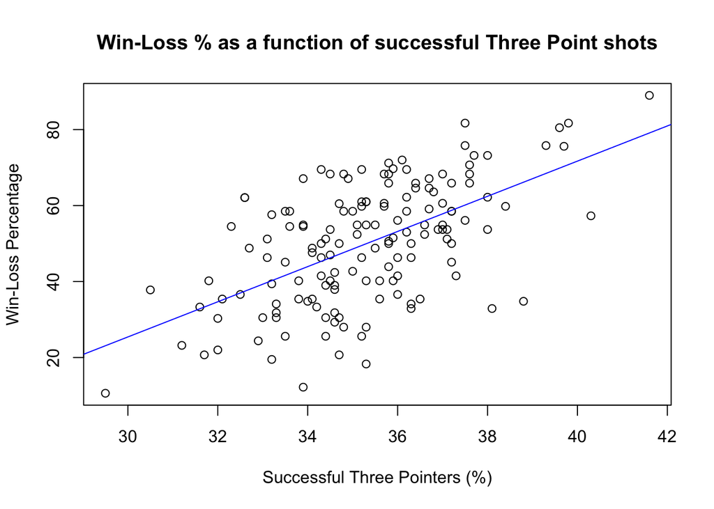

```r
plot(nba$ThreePerc, nba$Wlperc,
     xlab = "Successful Three Pointers (%)",
     ylab = "Win-Loss Percentage",
     main = "Win-Loss % as a function of successful Three Point shots")

model1 <- lm(Wlperc ~ ThreePerc, data = nba)
abline(model1, col = "blue")
```

```r
summary(model1)
```

```
##
## Call:
## lm(formula = Wlperc ~ ThreePerc, data = nba)
##
## Residuals:
##     Min      1Q  Median      3Q     Max
## -31.659  -8.798   0.000  10.428  24.642
##
## Coefficients:
##              Estimate Std. Error t value Pr(>|t|)
## (Intercept) -113.4768    19.1588  -5.923 2.12e-08 ***
## ThreePerc      4.6299     0.5418   8.546 1.45e-14 ***
## ---
## Signif. codes:  0 '***' 0.001 '**' 0.01 '*' 0.05 '.' 0.1 ' ' 1
##
## Residual standard error: 13 on 148 degrees of freedom
## Multiple R-squared:  0.3304, Adjusted R-squared:  0.3259
## F-statistic: 73.03 on 1 and 148 DF,  p-value: 1.448e-14
```

What model are we estimating?

$WinLoss_i = \beta_0 + \beta_1 ThreePerc_i + \epsilon_i$

What is our null hypothesis?

In words: the percentage of successful three-point shots made has no impact on the win-loss percentage.

In maths: $H_0: \beta_1 = 0$

What is our two-sided alternative hypothesis?

In words: the percentage of successful three-point shots made has an impact on the win-loss percentage.

In maths: $H_1: \beta_1 \neq 0$

5. We can also add a confidence interval. You won’t have to do this on your problem set or on an exam, but it helps us visualize the uncertainty of our estimates.

```r
plot(nba$ThreePerc, nba$Wlperc,
     xlab = "Successful Three Pointers (%)",
     ylab = "Win-Loss Percentage",
     main = "Win-Loss % as a function of successful Three Point shots")
abline(model1, col = "blue")
newx <- seq(20, 50, 1)
# Creates sequence of new x values between 20 and 50 with an interval of 1 (Why are 20 & 50? Hint: use range(nba$ThreePerc) to check the range of this variable.)

CI95 <- predict(model1,
                newdata = data.frame(ThreePerc = newx),
                interval = "confidence",
                level = 0.95) # Predicts fitted values for new x values
head(CI95)
```

```
##          fit        lwr        upr
## 1 -20.878484 -37.401907 -4.3550615
## 2 -16.248570 -31.710646 -0.7864938
## 3 -11.618655 -26.020756  2.7834456
## 4  -6.988741 -20.332565  6.3550835
## 5  -2.358826 -14.646512  9.9288589
## 6   2.271088  -8.963198 13.5053744
```

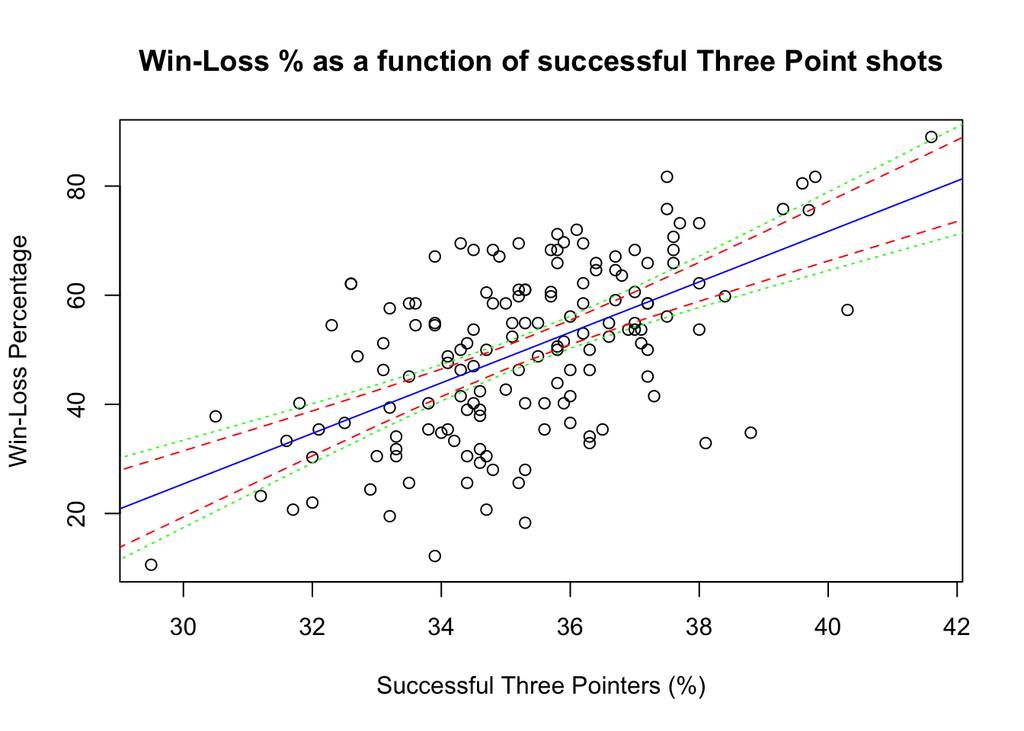

```r
# From left to right: fitted (or predicted) values, 95% lower-bound, 95% upper-bound
lines(newx, CI95[, 2], lty = 2, col = "red")
# Plot lower-bound for 95% confidence interval
lines(newx, CI95[ ,3], lty = 2, col = "red")
# Plot upper-bound for 95% confidence interval

CI99 <- predict(model1,
                newdata = data.frame(ThreePerc = newx),
                interval = "confidence",
                level = 0.99)
lines(newx, CI99[, 2], lty = 3, col = "green")
# CI99[, 2] grabs the second column
# The lty option sets the line type
lines(newx, CI99[, 3], lty = 3, col = "green")
```

Why is the 99% confidence interval wider than the 95% confidence one?

## Multivariate Regression

Multivariate regression is OLS with multiple independent variables.

*What is the advantage of multivariate regression?* Reduces bias and increases precision (more accurate parameter estimates), because the coefficient estimates are on average less far away from the true value. We know there are other factors besides shooting the three that matter for winning teams. We are taking these factors out of the error term and putting them into the model.

How to interpret multivariate OLS regression coefficients: A one unit increase in $X$ is associated with a $\hat{\beta}_1$ increase in $Y$, *holding other factors constant / ceteris paribus / all else being equal*.

6. Let’s create a multivariate model:

$WinLoss_i = \beta_0 + \beta_1 ThreePerc_i + \beta_2 Block_i + \epsilon_i$

```r
model2 <- lm(Wlperc ~ ThreePerc + BLK, data = nba)
summary(model2)
```

```
##
## Call:
## lm(formula = Wlperc ~ ThreePerc + BLK, data = nba)
##
## Residuals:
##     Min      1Q  Median      3Q     Max
## -35.696  -8.320   1.327   8.926  25.615
##
## Coefficients:
##               Estimate Std. Error t value Pr(>|t|)
## (Intercept) -119.30107   18.99658  -6.280 3.61e-09 ***
## ThreePerc      4.37489    0.54308   8.056 2.49e-13 ***
## BLK            0.03816    0.01564   2.440   0.0159 *
## ---
## Signif. codes:  0 '***' 0.001 '**' 0.01 '*' 0.05 '.' 0.1 ' ' 1
##
## Residual standard error: 12.79 on 147 degrees of freedom
## Multiple R-squared:  0.3565, Adjusted R-squared:  0.3477
## F-statistic: 40.71 on 2 and 147 DF,  p-value: 8.504e-15
```

How do we interpret $\hat{\beta}_1$?

A 1 percentage point increase in successful three-point shots is associated with a 4.37 percentage point increase in win-loss percentage, holding everything else constant.

7. We may think that the fan support plays a role in a team’s winning percentage. Including another variable of $Attendance_i$ allows us to control for fan support.

```r
model3 <- lm(Wlperc ~ ThreePerc + BLK + Attendance, data = nba)
summary(model3)
```

```
##
## Call:
## lm(formula = Wlperc ~ ThreePerc + BLK + Attendance, data = nba)
##
## Residuals:
##     Min      1Q  Median      3Q     Max
## -32.788  -8.098   0.854   8.159  29.076
##
## Coefficients:
##               Estimate Std. Error t value Pr(>|t|)
## (Intercept) -1.188e+02  1.862e+01  -6.382 2.18e-09 ***
## ThreePerc    3.892e+00  5.623e-01   6.922 1.31e-10 ***
## BLK          2.645e-02  1.595e-02   1.659  0.09929 .
## Attendance   3.053e-05  1.148e-05   2.660  0.00868 **
## ---
## Signif. codes:  0 '***' 0.001 '**' 0.01 '*' 0.05 '.' 0.1 ' ' 1
##
## Residual standard error: 12.54 on 146 degrees of freedom
## Multiple R-squared:  0.3862, Adjusted R-squared:  0.3736
## F-statistic: 30.62 on 3 and 146 DF,  p-value: 2.038e-15
```

What happens to the coefficient estimates on $ThreePerc_i$ and $BLK_i$ when we include $Attendance_i$? What about statistical significance?

Bonus question: what is the meaning of R-squared?